# INN Hotels Project

## Question 6: Many guests have special requirements when booking a hotel room. Do these requirements affect booking cancelation?

Null hypothesis:

> $H_0:$ Number of special requests is independent of booking status.

Alternate hypothesis:

> $H_a:$ Number of special requests depends on booking status.

```python
from scipy.stats import chi2_contingency

bookings_special_request_booking_status = pd.crosstab(
    index=data["booking_status"], columns=data["no_of_special_requests"]
)
print(bookings_special_request_booking_status)

# df_language_preferred_converted.value_counts().drop("converted", axis=1)
chi, p_value, dof, expected = chi2_contingency(bookings_special_request_booking_status)
print("The p-value is", p_value)
```

```
no_of_special_requests      0     1     2    3   4  5
booking_status
0                       11232  8670  3727  675  78  8
1                        8545  2703   637    0   0  0
The p-value is 0.0
```

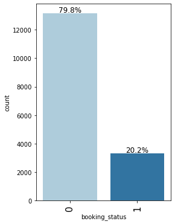

```python
labeled_barplot(
    data[data["no_of_special_requests"] != 0], "booking_status", perc=True
)  # creates a labeled barplot showing the booking status's with it's coresponding percentages
```

[output not shown]

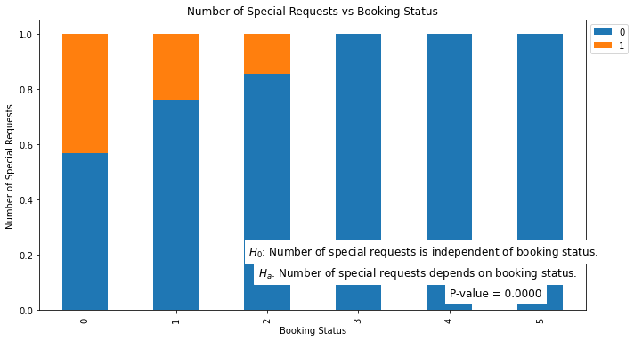

```python
# creates stacked barplot of booking status with respect to number of special requests
count = data["no_of_special_requests"].nunique()
sorter = data["booking_status"].value_counts().index[-1]
tab1 = pd.crosstab(
    data["no_of_special_requests"], data["booking_status"], margins=True
).sort_values(by=sorter, ascending=False)
print(tab1)
print("-" * 120)
tab = pd.crosstab(
    data["no_of_special_requests"], data["booking_status"], normalize="index"
).sort_values(by=sorter, ascending=False)
tab.plot(kind="bar", stacked=True, figsize=(count + 5, 6))
plt.legend(
    loc="lower left", frameon=False,
)
plt.legend(loc="upper left", bbox_to_anchor=(1, 1))

plt.title("Number of Special Requests vs Booking Status")  # sets title
plt.xlabel("Booking Status")  # sets x label
plt.ylabel("Number of Special Requests")  # sets y label

# adds text box for null hypothesis, alternative hypothesis, and p-value
plt.text(
    x=1.8,
    y=0.2,
    s="$H_0$: Number of special requests is independent of booking status.",
    backgroundcolor="white",
    fontsize="large",
)
plt.text(
    x=1.9,
    y=0.125,
    s="$H_a$: Number of special requests depends on booking status.",
    backgroundcolor="white",
    fontsize="large",
)
plt.text(
    x=4,
    y=0.05,
    s="P-value = {:.4f}".format(p_value),
    backgroundcolor="white",
    fontsize="large",
)

plt.savefig(
    "special_requests_per_booking_status.jpg", bbox_inches="tight"
)  # save graph as JPEG
plt.show()
```

[output not shown]

### Observations:

**Since the p-value, for the chi-square test of independence, is 0. which is less than 0.05, It is safe to assume that the number of special requests does effect the booking status.**

**The graph shows that any amount of special requests causes a sharp decrease in the amount of cancelations.**

## Data Preprocessing

- Missing value treatment (if needed)
- Feature engineering (if needed)
- Outlier detection and treatment (if needed)
- Preparing data for modeling
- Any other preprocessing steps (if needed)

```python
data = data[data["no_of_children"] != 9]
data = data[data["no_of_children"] != 10]
bookings = data[data["no_of_previous_cancellations"] != 13]
```

```python
# creates dictionary showing what rows get replaced with in their given columns
replaceStruct = {
    "type_of_meal_plan": {
        "Meal Plan 1": 1,
        "Meal Plan 2": 2,
        "Meal Plan 3": 3,
        "Not Selected": -1,
    },
    "room_type_reserved": {
        "Room_Type 1": 1,
        "Room_Type 2": 2,
        "Room_Type 3": 3,
        "Room_Type 4": 4,
        "Room_Type 5": 5,
        "Room_Type 6": 6,
        "Room_Type 7": 7,
    },
    "booking_status": {"Not_Canceled": 0, "Canceled": 1},
}

# replaces values with the replaceStruct dictionary made above
data = data.replace(replaceStruct)

data.head()  # shows head of dataframe bookings
```

|  | no_of_adults | no_of_children | no_of_weekend_nights | no_of_week_nights | type_of_meal_plan | required_car_parking_space | room_type_reserved | lead_time | arrival_year | arrival_month | arrival_date | market_segment_type | repeated_guest | no_of_previous_cancellations | no_of_previous_bookings_not_canceled | avg_price_per_room | no_of_special_requests | booking_status |
| --- | --- | --- | --- | --- | --- | --- | --- | --- | --- | --- | --- | --- | --- | --- | --- | --- | --- | --- |
| 0 | 2 | 0 | 1 | 2 | 1 | 0 | 1 | 224 | 2017 | 10 | 2 | Offline | 0 | 0 | 0 | 65.00000 | 0 | 0 |
| 1 | 2 | 0 | 2 | 3 | -1 | 0 | 1 | 5 | 2018 | 11 | 6 | Online | 0 | 0 | 0 | 106.68000 | 1 | 0 |
| 2 | 1 | 0 | 2 | 1 | 1 | 0 | 1 | 1 | 2018 | 2 | 28 | Online | 0 | 0 | 0 | 60.00000 | 0 | 1 |
| 3 | 2 | 0 | 0 | 2 | 1 | 0 | 1 | 211 | 2018 | 5 | 20 | Online | 0 | 0 | 0 | 100.00000 | 0 | 1 |
| 4 | 2 | 0 | 1 | 1 | -1 | 0 | 1 | 48 | 2018 | 4 | 11 | Online | 0 | 0 | 0 | 94.50000 | 0 | 1 |

### Outlier detection and treatment if need be

- Let's check for outliers in the data for lead time and average price.

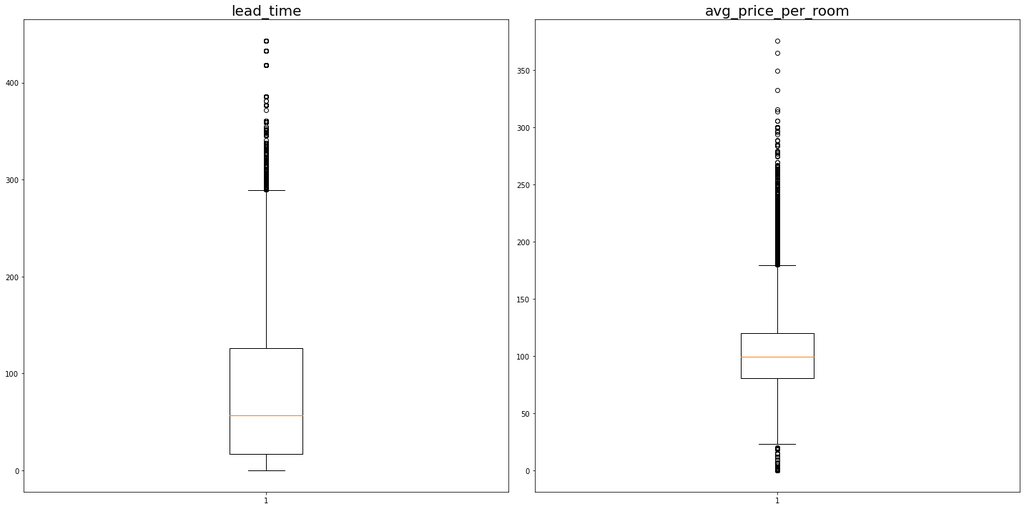

```python
# create list of all numerical column names
numeric_cols = ["lead_time", "avg_price_per_room"]

plt.figure(figsize=(20, 10))

# print boxplots of all numerical values
for i, variable in enumerate(numeric_cols):
    plt.subplot(1, 2, i + 1)
    plt.boxplot(bookings[variable], whis=1.5)
    plt.tight_layout()
    plt.title(variable, fontsize=20)

plt.show()  # create list of all numerical column names
```

```python
def treat_outliers(df, col):
    """
    treats outliers in a variable
    col: str, name of the numerical variable
    df: dataframe
    col: name of the column
    """
    Q1 = df[col].quantile(0.25)  # 25th quantile
    Q3 = df[col].quantile(0.75)  # 75th quantile
    IQR = Q3 - Q1
    Lower_Whisker = Q1 - 1.5 * IQR
    Upper_Whisker = Q3 + 1.5 * IQR

    # all the values smaller than Lower_Whisker will be assigned the value of Lower_Whisker
    # all the values greater than Upper_Whisker will be assigned the value of Upper_Whisker
    df[col] = np.clip(df[col], Lower_Whisker, Upper_Whisker)

    return df


def treat_outliers_all(df, col_list):
    """
    treat outlier in all numerical variables
    col_list: list of numerical variables
    df: data frame
    """
    #   use treat_outliers on all columns in col_list in dataframe df
    for c in col_list:
        df = treat_outliers(df, c)

    return df
```

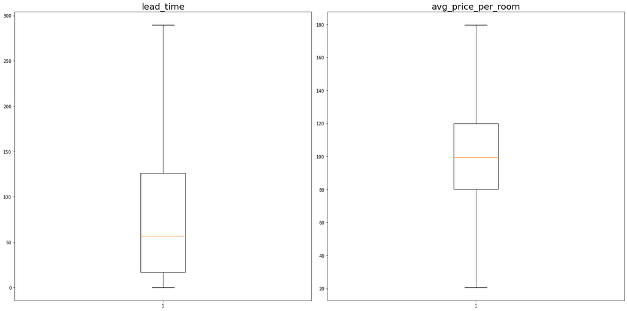

```python
data = treat_outliers_all(
    data, numeric_cols
)  # set outliers to level of whiskers for all numeric columns except for ram

plt.figure(figsize=(20, 10))

# print boxplots of all numerical values
for i, variable in enumerate(numeric_cols):
    plt.subplot(1, 2, i + 1)
    plt.boxplot(data[variable], whis=1.5)
    plt.tight_layout()
    plt.title(variable, fontsize=20)

plt.show()
```

```python
data["lead_time"].value_counts().reset_index().sort_values(by="index", ascending=False)
```

|  | index | lead_time |
| --- | --- | --- |
| 0 | 289.50000 | 1331 |
| 265 | 289.00000 | 15 |
| 287 | 288.00000 | 5 |
| 277 | 287.00000 | 10 |
| 209 | 286.00000 | 41 |
| ... | ... | ... |
| 5 | 4.00000 | 628 |
| 4 | 3.00000 | 630 |
| 3 | 2.00000 | 643 |
| 2 | 1.00000 | 1078 |
| 1 | 0.00000 | 1297 |

291 rows × 2 columns

```python
data["avg_price_per_room"].value_counts().reset_index().sort_values(
    by="index", ascending=False
)
```

|  | index | avg_price_per_room |
| --- | --- | --- |
| 0 | 179.55000 | 1069 |
| 3457 | 179.50000 | 1 |
| 2926 | 179.38000 | 1 |
| 2983 | 179.30000 | 1 |
| 2132 | 179.25000 | 1 |
| ... | ... | ... |
| 359 | 31.00000 | 11 |
| 3300 | 29.00000 | 1 |
| 2611 | 26.35000 | 1 |
| 2212 | 23.00000 | 1 |
| 6 | 20.75000 | 627 |

3513 rows × 2 columns

```python
# takes out the mx value for the avg price per room, because it seems too far awya from teh rest of the outliers.
data = data[data["avg_price_per_room"] != 540.00]
```

```python
data = pd.get_dummies(
    data, columns=["market_segment_type"], drop_first=True
)  # create dummy columns for all categorical columns
data
```

|  | no_of_adults | no_of_children | no_of_weekend_nights | no_of_week_nights | type_of_meal_plan | required_car_parking_space | room_type_reserved | lead_time | arrival_year | arrival_month | arrival_date | repeated_guest | no_of_previous_cancellations | no_of_previous_bookings_not_canceled | avg_price_per_room | no_of_special_requests | booking_status | market_segment_type_Complementary | market_segment_type_Corporate | market_segment_type_Offline | market_segment_type_Online |
| --- | --- | --- | --- | --- | --- | --- | --- | --- | --- | --- | --- | --- | --- | --- | --- | --- | --- | --- | --- | --- | --- |
| 0 | 2 | 0 | 1 | 2 | 1 | 0 | 1 | 224.00000 | 2017 | 10 | 2 | 0 | 0 | 0 | 65.00000 | 0 | 0 | 0 | 0 | 1 | 0 |
| 1 | 2 | 0 | 2 | 3 | -1 | 0 | 1 | 5.00000 | 2018 | 11 | 6 | 0 | 0 | 0 | 106.68000 | 1 | 0 | 0 | 0 | 0 | 1 |
| 2 | 1 | 0 | 2 | 1 | 1 | 0 | 1 | 1.00000 | 2018 | 2 | 28 | 0 | 0 | 0 | 60.00000 | 0 | 1 | 0 | 0 | 0 | 1 |
| 3 | 2 | 0 | 0 | 2 | 1 | 0 | 1 | 211.00000 | 2018 | 5 | 20 | 0 | 0 | 0 | 100.00000 | 0 | 1 | 0 | 0 | 0 | 1 |
| 4 | 2 | 0 | 1 | 1 | -1 | 0 | 1 | 48.00000 | 2018 | 4 | 11 | 0 | 0 | 0 | 94.50000 | 0 | 1 | 0 | 0 | 0 | 1 |
| ... | ... | ... | ... | ... | ... | ... | ... | ... | ... | ... | ... | ... | ... | ... | ... | ... | ... | ... | ... | ... | ... |
| 36270 | 3 | 0 | 2 | 6 | 1 | 0 | 4 | 85.00000 | 2018 | 8 | 3 | 0 | 0 | 0 | 167.80000 | 1 | 0 | 0 | 0 | 0 | 1 |
| 36271 | 2 | 0 | 1 | 3 | 1 | 0 | 1 | 228.00000 | 2018 | 10 | 17 | 0 | 0 | 0 | 90.95000 | 2 | 1 | 0 | 0 | 0 | 1 |
| 36272 | 2 | 0 | 2 | 6 | 1 | 0 | 1 | 148.00000 | 2018 | 7 | 1 | 0 | 0 | 0 | 98.39000 | 2 | 0 | 0 | 0 | 0 | 1 |
| 36273 | 2 | 0 | 0 | 3 | -1 | 0 | 1 | 63.00000 | 2018 | 4 | 21 | 0 | 0 | 0 | 94.50000 | 0 | 1 | 0 | 0 | 0 | 1 |
| 36274 | 2 | 0 | 1 | 2 | 1 | 0 | 1 | 207.00000 | 2018 | 12 | 30 | 0 | 0 | 0 | 161.67000 | 0 | 0 | 0 | 0 | 1 | 0 |

36275 rows × 21 columns

### lead time

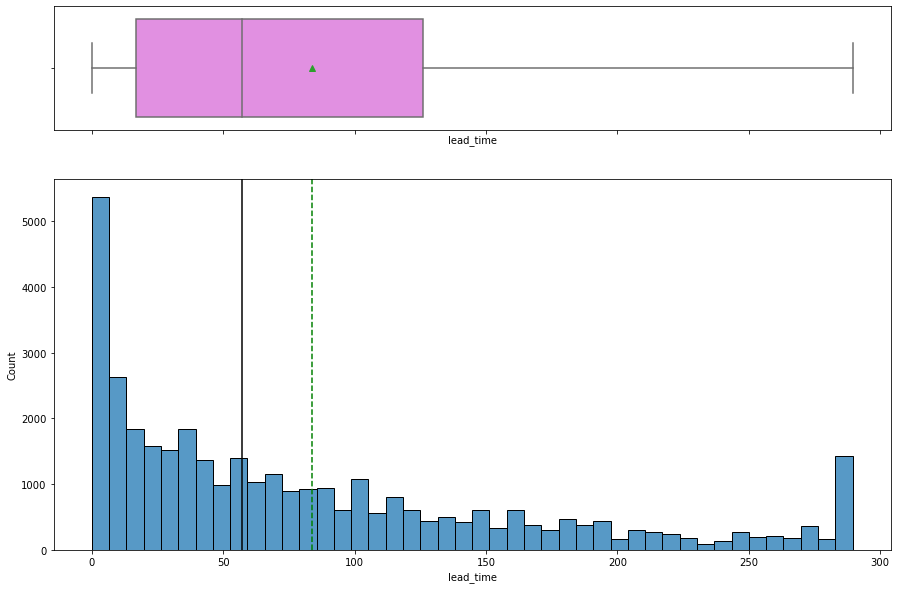

```python
histogram_boxplot(
    data, "lead_time"
)  # plots boxplot and histogram of no_of_weekend_nights
```

### average price

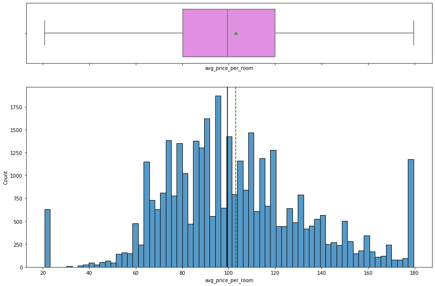

```python
histogram_boxplot(
    data, "avg_price_per_room"
)  # plots boxplot and histogram of no_of_weekend_nights
```

### no of children

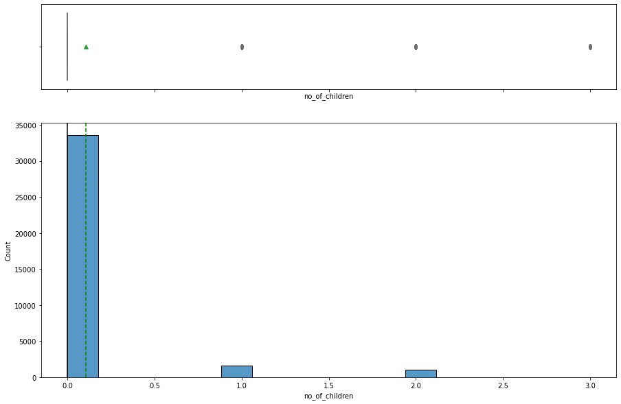

```python
histogram_boxplot(
    data, "no_of_children"
)  # plots boxplot and histogram of no_of_weekend_nights
```

### type of meal plan

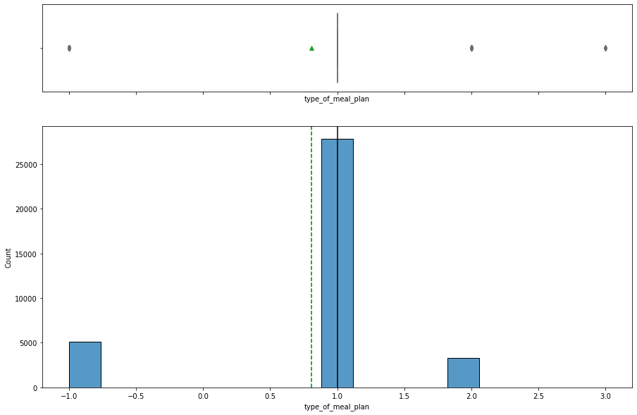

```python
histogram_boxplot(
    data, "type_of_meal_plan"
)  # plots boxplot and histogram of no_of_weekend_nights
```

### room type reserved

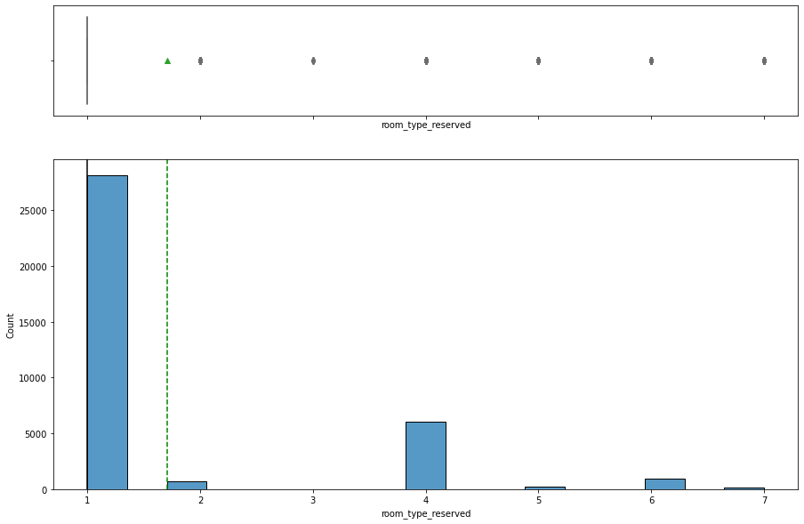

```python
histogram_boxplot(
    data, "room_type_reserved"
)  # plots boxplot and histogram of no_of_weekend_nights
```

### booking status

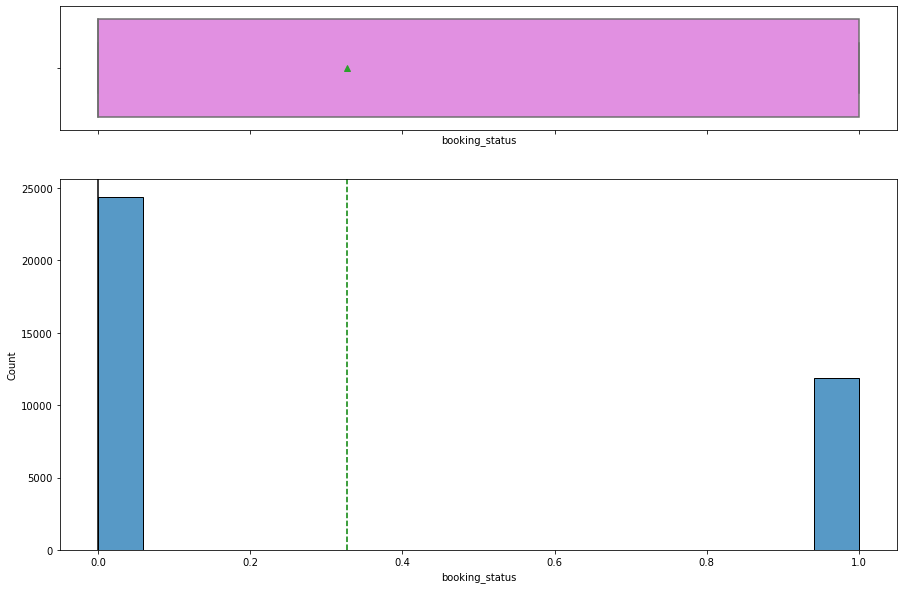

```python
histogram_boxplot(
    data, "booking_status"
)  # plots boxplot and histogram of no_of_weekend_nights
```

```
booking_status      0      1    All
no_of_children
All             24390  11885  36275
0               22695  10882  33577
1                1078    540   1618
2                 601    457   1058
3                  16      6     22
------------------------------------------------------------------------------------------------------------------------
```

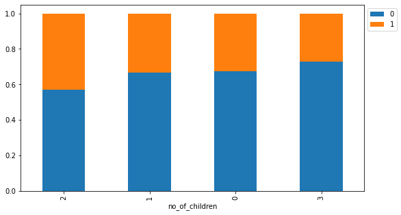

```python
stacked_barplot(
    data, "no_of_children", "booking_status"
)  # creates stacked barplot of booking status with respect to market segment type
```

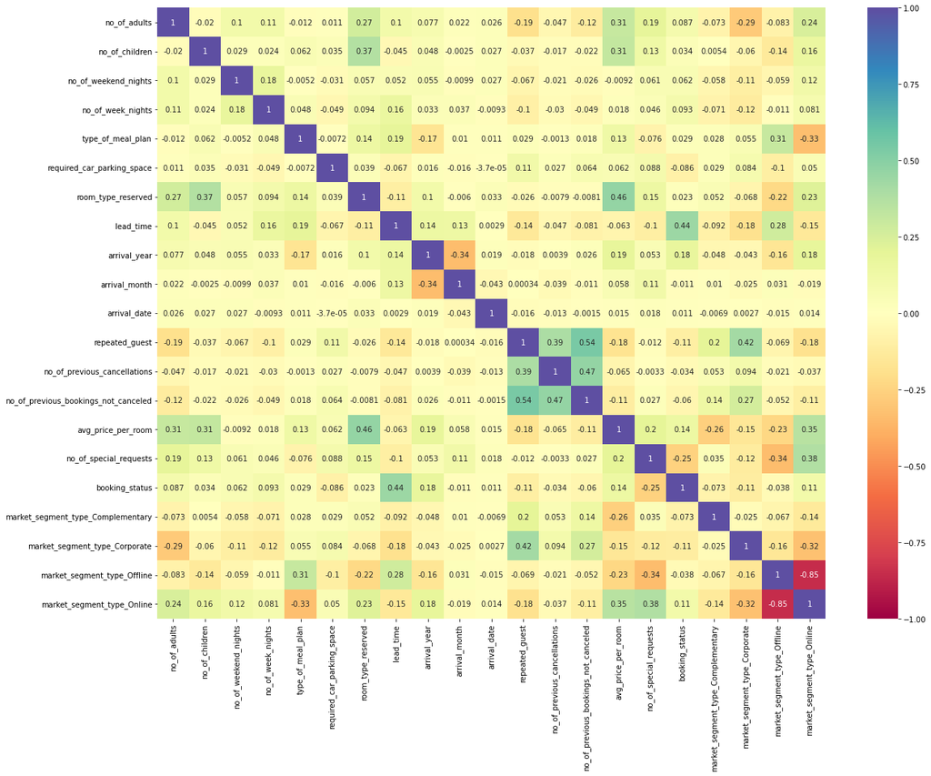

```python
# creates heatmap showing corralation of data in bookings
plt.figure(figsize=(20, 15))
sns.heatmap(data.corr(), annot=True, vmin=-1, vmax=1, cmap="Spectral")
plt.show()
```

### observation

**There exist a negative correlation between the booking status and the number of special request from a client. This is a relationship which shows that a customer who made a special request has low chances of cancelling the booking**